# Complexity metrics for DEMs

```r
library(habtools)
library(raster)
library(dplyr)
library(ggplot2)
```

DEM_intro.R

In this vignette, we go over the basic steps to calculate standard complexity metrics for digital elevation models (DEMs). In this example, we use a DEM of 8x8m with a resolution of 0.01m.

```r
# Load a raster
dem <- horseshoe
res(dem)
```

```
#> [1] 0.01 0.01
```

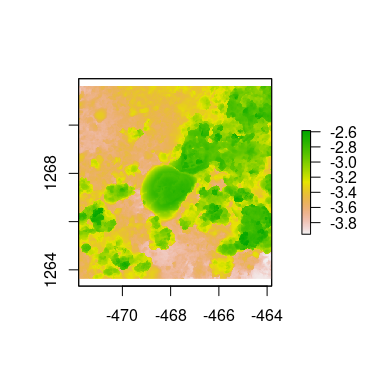

```r
plot(dem)
```

DEM_intro.R

Let’s say we want complexity metrics for a certain square of size 2m around certain xy-coordinates. We can start by using the `dem_crop()` function.

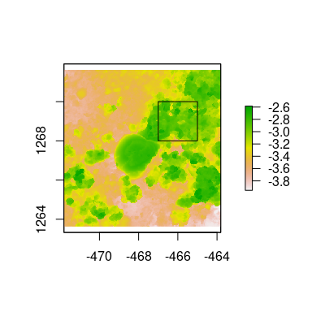

```r
dem1 <- dem_crop(horseshoe, x0 = -466, y0 = 1269, L = 2, plot = TRUE)
```

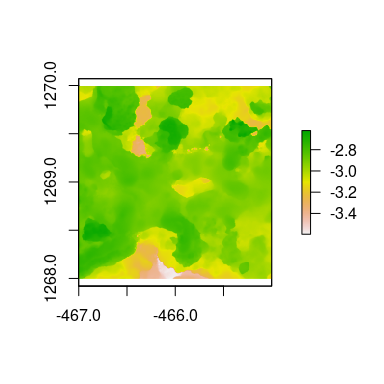

```r
plot(dem1)
```

DEM_intro.R

## Height range

```r
hr(dem1)
```

```
#> [1] 0.9766939
```

DEM_intro.R

## Rugosity

```r
# Height variation method
rg(dem1, method = "hvar", L0 = 0.05, parallel = FALSE) # Parallel = TRUE enables parallel processing using multiple cores to speed up the calculations using the height variation method. Only use this if you have a powerful computer with at least four cores.
```

```
#> [1] 1.6123
```

```r
# Area method
rg(dem1, method = "area", L0 = 0.05)
```

```
#> [1] 1.619947
```

DEM_intro.R

## Fractal dimension

The fractal dimension metric provides information about how a surface fills a volume and indicates how space varies over various scales. `habtools` provides different methods to estimate fractal dimension and the result may change depending on the method chosen. See the vignette on fractal dimension for more examples of how the results of different methods vary. Below we focus on two methods: `hvar` and `area`.

### Height variation method

The height variation method is based on the relationship between height range and scale. Basically, the DEM is divided into small squares with sizes specified in `lvec`. Within each square, the height range is calculated and logged. This results in a data frame with many height ranges (depending on the scale). This data is then summarized by taking the mean or median. The fractal dimension is finally calculated as:
$$D = 3- b,$$
with b being the slope of the linear regression between height range (h) and scale (l) $log(h) \sim log(l)$. Because a range of values is needed to calculate a height range the smallest value of `lvec` should always be at least two times the resolution of the DEM, and up to 10 times bigger. The largest value should be the extent of the DEM square. We suggest to choose a vector of doubling values for `lvec`. For example, if the resolution = 0.01m and the extent = 2m, we could choose `lvec` = `c(0.0625, 0.125, 0.25, 0.5, 1, 2)`. However, to speed the example up, we will use one order of magnitude with `lvec` = `c(0.25, 0.5, 1, 2)`.

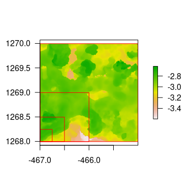

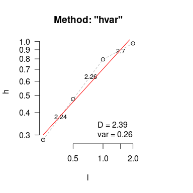

```
#> $D
#> [1] 2.387569
#>
#> $data
#>      l         h
#> 1 0.25 0.2814564
#> 2 0.50 0.4762113
#> 3 1.00 0.7949864
#> 4 2.00 0.9766939
#>
#> $lvec
#> [1] 0.25 0.50 1.00 2.00
#>
#> $D_vec
#> [1] 2.241310 2.260672 2.703024
#>
#> $var
#> [1] 0.2611609
#>
#> $method
#> [1] "hvar"
```

```r
# Height variation method
fd(dem1, method = "hvar", lvec = c(0.25, 0.5, 1, 2), plot = TRUE, diagnose = TRUE)
```

DEM_intro.R

`diagnose=TRUE` allows us to visualize the calculation and model fit. This also allows us to investigate any scale transitions in fractal dimension and provides a list of information including the estimated fractal dimension (D), the data used for the regression, the `lvec`, the `D_vec` (vector of fractal dimensions across scales), the variance of the fractal dimensions across scales, and the method used.

### Area method

The area method operates quite differently to height variation, and is therefore not comparable to the height variation method described above. This method uses surface areas at varying scales and calculates the fractal dimension as:
$$D = 2 -
b,$$
where b is the slope of the linear regression between surface area (a) and scale (l): $log(a) \sim log(l)$.

The surface area is calculated at each scale by projecting the DEM to the resolution of that scale. Similar to the above method, we suggest a doubling vector for `lvec`. However, the smallest scale can be as small as the resolution of the DEM and the largest scale should not approach the extent DEM (ideally it stays 4 to 8 times smaller than the extent).

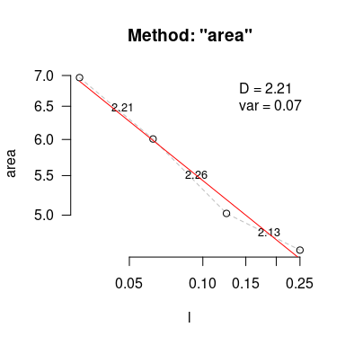

```
#> $D
#> [1] 2.20583
#>
#> $data
#>         l     area
#> 1 0.03125 6.964329
#> 2 0.06250 6.006999
#> 3 0.12500 5.020314
#> 4 0.25000 4.595348
#>
#> $lvec
#> [1] 0.03125 0.06250 0.12500 0.25000
#>
#> $D_vec
#> [1] 2.213340 2.258867 2.127604
#>
#> $var
#> [1] 0.06665026
#>
#> $method
#> [1] "area"
```

```r
# Area method
fd(dem1, method = "area", lvec = c(0.03125, 0.0625, 0.125, 0.25), diagnose = TRUE)
```

DEM_intro.R

## Multiple metrics

It is possible to calculate these three metrics by using the `rdh()` function. Note that the resolution (`L0`) for the rugosity calculation will be set as the smallest value of `lvec` if `method_rg` is set to `"hvar"`. This can decrease the estimate of R.

DEM_intro.R

```r
rdh(dem1, lvec = c(0.125, 0.25, 0.5, 1, 2), method_fd = "hvar", method_rg = "hvar")
```

```
#> fd calculation using hvar method.
#> rg calculation using hvar method.
#> L0 is set to 0.125.
#>          R        D         H
#> 1 1.552032 2.300395 0.9766939
```

```r
rdh(dem1, lvec = c( 0.125, 0.25, 0.5, 1, 2), method_fd = "hvar")
```

```
#> fd calculation using hvar method.
#> rg calculation using area method.
#> L0 is set to the resolution of the raster: 0.01.
#>         R        D         H
#> 1 2.12501 2.300395 0.9766939
```

```r
rdh(dem1, lvec = c(0.03125, 0.0625, 0.125, 0.25), method_fd = "area")
```

[output not shown]

DEM_intro.R

## Multiple squares

The function `dem_split()` allows you to subdivide a DEM into equal parts. Let’s divide the big raster into 2x2m squares. Note that this function will only work well if you have a square DEM. You also want to choose the size so that the DEM can be divided into equal parts. You can then calculate metrics for the list of DEMs.

```r
dem_list <- dem_split(dem, size = 2)
# calculate one metric for all squares
sapply(dem_list, hr)
```

```
#>  [1] 0.5169916 0.6127143 0.8386080 0.8948445 0.6774139 0.9407241 0.9958875
#>  [8] 0.9968965 1.1133885 1.0766172 1.1218033 1.0029795 0.9923670 1.1646364
#> [15] 0.9986641 1.3692834
```

```r
# calculate multiple metrics
data_rdh <- suppressMessages(lapply(dem_list, rdh, method_fd = "hvar", lvec = c(0.25, 0.5, 1, 2))) %>%
  bind_rows()
```

DEM_intro.R

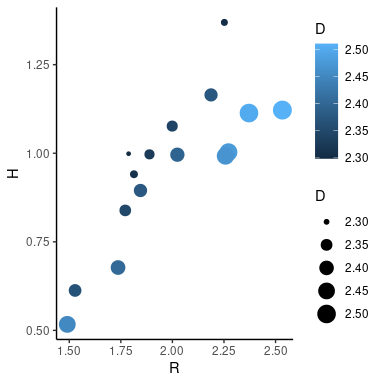

```r
ggplot(data_rdh) +
  geom_point(aes(x = R, y = H, color = D, size = D)) +
  theme_classic()
```

DEM_intro.R

## Sample a random square

`habtools` also provides a way to crop a random square out of a DEM.

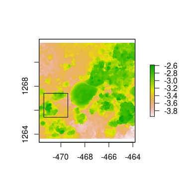

```r
dem <- dem_sample(horseshoe, L=2, plot=TRUE)
```

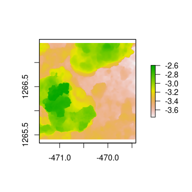

```r
plot(dem)
```

DEM_intro.R

## Rules of thumb

- When analyzing and comparing multiple DEMs, make sure that each DEM has the same resolution and extent.
- When using the `hvar` method, the smallest value of `lvec` should be between two times and ten higher than the resolution.
- When using the `hvar` method, the extent (highest value of `lvec`) should ideally be 1 to 2 orders of magnitudes higher compared to smallest value of `lvec`.
- `lvec` values should match scales of particular interest (e.g. matching body sizes of animals inhabiting the surface).
- When using the `area` method, the `lvec` can range from the resolution to around 1/8 of the extent. Higher scales will increase bias of the method.
- `lvec` and chosen method needs to be the same across all calculations to make comparisons among DEMs.